# Diagnóstico del uso y apropiación de Inteligencia Artificial en el personal administrativo

**Análisis exploratorio de datos (EDA) – Encuesta diagnóstica sobre uso de IA en procesos administrativos**

**Objetivo:** identificar el nivel actual de conocimiento, uso y apropiación de herramientas de IA por parte del personal administrativo, así como las principales oportunidades, necesidades y riesgos para fortalecer su incorporación en los procesos institucionales.

**Contenido**

1. Carga y revisión de calidad de datos
2. Perfil de los participantes
3. Nivel de uso y frecuencia
4. Herramientas y actividades
5. Competencias autopercibidas
6. Beneficios y cambio en la forma de trabajar
7. Barreras, riesgos y gobernanza
8. Oportunidades y necesidades de apoyo
9. Tareas repetitivas propuestas (pregunta abierta)
10. Segmentación por nivel de apropiación y cruces
11. Conclusiones

```python
import glob, re, unicodedata, warnings, textwrap
from collections import Counter
import numpy as np, pandas as pd
import matplotlib.pyplot as plt, seaborn as sns
from scipy import stats
warnings.filterwarnings('ignore')

sns.set_theme(style='whitegrid', context='notebook')
plt.rcParams.update({'figure.dpi':110,'axes.titleweight':'bold','axes.titlesize':12,'axes.spines.top':False,'axes.spines.right':False})
AZUL, NARANJA, GRIS = '#2F5D8A', '#E08A2E', '#9AA5B1'
pd.set_option('display.max_colwidth', 100); pd.set_option('display.width', 200)

# Versión anonimizada de la encuesta (la que se publica en el repositorio; ver anonimizar_encuesta.py)
ruta = 'Encuesta_IA_anonimizada.xlsx'
raw = pd.read_excel(ruta)
print(ruta); print('Filas, columnas:', raw.shape)
raw.head(3)
```

```
Encuesta_IA_anonimizada.xlsx
Filas, columnas: (226, 25)
```

|  | ID | Hora de inicio | Hora de finalización | Correo electrónico | Nombre | Hora de la última modificación | Unidad o dependencia en la que trabaja: | Tipo de funciones que desarrolla principalmente: | ¿Ha utilizado herramientas de inteligencia artificial para apoyar actividades relacionadas con su trabajo? | ¿Con qué frecuencia utiliza IA en actividades laborales? | ... | Utilizar IA para analizar información o datos | Identificar cuándo no es apropiado utilizar IA | Proteger información institucional, personal o confidencial al usar IA | Cuando utiliza IA, ¿qué beneficios ha experimentado? (Puede seleccionar varios) | En términos generales, ¿cuánto considera que la IA ha cambiado su forma de trabajar? | ¿Qué le dificulta utilizar más o mejor la IA en su trabajo? (Seleccione máximo 3) | ¿Tiene claridad sobre las orientaciones institucionales para el uso responsable y seguro de IA? | Pensando en sus funciones actuales, ¿en cuáles actividades considera que la IA podría ayudarle más, aunque todavía no la utilice para ello? (Puede seleccionar varios)\n | ¿Qué tipo de apoyo considera prioritario para fortalecer el uso de IA en su trabajo? (Seleccione máximo 2) | Mencione una tarea o proceso de su trabajo que actualmente le tome mucho tiempo o sea repetitivo y que considere que podría mejorarse con inteligencia artificial. |
| --- | --- | --- | --- | --- | --- | --- | --- | --- | --- | --- | --- | --- | --- | --- | --- | --- | --- | --- | --- | --- | --- |
| 0 | 1 | 2026-09-28 17:51:22 | 2026-09-28 17:53:01 | NaN | NaN | NaN | autoevaluacion y acreditacion | Profesionales | Sí, ocasionalmente | Varias veces por semana | ... | Media | Media | Media | Mejor calidad de documentos o productos; | Algo | Me preocupa la privacidad o seguridad de la información; | Parcialmente | Elaboración y revisión de documentos; | Formación básica sobre IA; | NaN |
| 1 | 2 | 2026-09-28 17:51:40 | 2026-09-28 17:53:02 | NaN | NaN | NaN | sistemas y tecnologia | Profesionales | Sí, frecuentemente | Todos o casi todos los días | ... | Media | Media | Media | Ahorro de tiempo;Mejor calidad de documentos o productos;Generación de nuevas ideas o alternativ... | Bastante | No sé suficientemente cómo utilizarla;No sé qué herramientas son adecuadas;Falta de tiempo para ... | Parcialmente | Elaboración y revisión de documentos;Elaboración de informes;Apoyo a la toma de decisiones; | Formación práctica aplicada a mis funciones;Guías sobre seguridad, privacidad y uso responsable; | NaN |
| 2 | 3 | 2026-09-28 17:51:52 | 2026-09-28 17:53:39 | NaN | NaN | NaN | control interno | Pasante | Sí, ocasionalmente | Varias veces al mes | ... | Media | Media | Media | Mayor facilidad para analizar información; | Bastante | Me preocupa que las respuestas sean incorrectas; | Sí, completamente | Atención y respuesta a usuarios;Gestión y análisis de información; | Formación avanzada en automatización y agentes de IA;Guías sobre seguridad, privacidad y uso res... | NaN |

3 rows × 25 columns

## 1. Carga y calidad de datos

**Preguntas de la encuesta utilizadas en esta sección**

| Gráfica / análisis | Pregunta(s) usada(s) |
| --- | --- |
| Tabla de nulos y duplicados | Todas las preguntas (P1 a P19) |
| Histograma de tiempo de diligenciamiento | Campos automáticos del formulario: hora de inicio y hora de finalización (no es una pregunta) |

```python
# Renombrar columnas a nombres cortos
cols = {
 raw.columns[6]:'unidad', raw.columns[7]:'funciones', raw.columns[8]:'uso_ia', raw.columns[9]:'frecuencia',
 raw.columns[10]:'herramientas', raw.columns[11]:'actividades', raw.columns[12]:'forma_uso',
 raw.columns[13]:'comp_instruccion', raw.columns[14]:'comp_evaluar', raw.columns[15]:'comp_analizar',
 raw.columns[16]:'comp_limites', raw.columns[17]:'comp_proteger', raw.columns[18]:'beneficios',
 raw.columns[19]:'cambio_trabajo', raw.columns[20]:'barreras', raw.columns[21]:'claridad_inst',
 raw.columns[22]:'oportunidades', raw.columns[23]:'apoyos', raw.columns[24]:'tarea_abierta'}
df = raw.rename(columns=cols)[['ID','Hora de inicio','Hora de finalización']+list(cols.values())].copy()
df['duracion_min'] = (df['Hora de finalización']-df['Hora de inicio']).dt.total_seconds()/60

print('Descartadas: Correo (todo "anonymous"), Nombre y Última modificación (100% vacías)')
print('IDs duplicados:', df['ID'].duplicated().sum(), '| filas de respuestas duplicadas:', df.drop(columns=['ID','Hora de inicio','Hora de finalización','duracion_min']).duplicated().sum())
nulos = df.isna().sum().pipe(lambda s: s[s>0]).to_frame('nulos'); nulos['%']=(nulos['nulos']/len(df)*100).round(1)
nulos
```

```
Descartadas: Correo (todo "anonymous"), Nombre y Última modificación (100% vacías)
IDs duplicados: 0 | filas de respuestas duplicadas: 0
```

|  | nulos | % |
| --- | --- | --- |
| uso_ia | 1 | 0.4 |
| forma_uso | 1 | 0.4 |
| comp_proteger | 1 | 0.4 |
| barreras | 3 | 1.3 |
| claridad_inst | 1 | 0.4 |
| oportunidades | 1 | 0.4 |
| tarea_abierta | 79 | 35.0 |

```
Encuestas recibidas: 226 | Periodo: 2026-09-28 17:51:22 → 2026-09-28 20:48:37
count    226.0
mean       5.3
std        5.4
min        1.0
25%        3.8
50%        4.7
75%        5.6
max       79.9
```

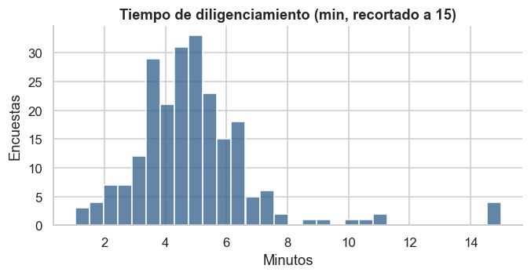

```python
print('Encuestas recibidas:', len(df), '| Periodo:', df['Hora de inicio'].min(), '→', df['Hora de finalización'].max())
print(df['duracion_min'].describe().round(1).to_string())
fig, ax = plt.subplots(figsize=(7,3))
sns.histplot(df['duracion_min'].clip(upper=15), bins=30, color=AZUL, ax=ax)
ax.set(title='Tiempo de diligenciamiento (min, recortado a 15)', xlabel='Minutos', ylabel='Encuestas'); plt.show()
```

### Limpieza y transformación

```python
def sin_tildes(s):
    return ''.join(c for c in unicodedata.normalize('NFD', s) if unicodedata.category(c)!='Mn')

# Funciones: unificar variantes y agrupar categorías con muy pocos casos en "Otras"
def norm_func(x):
    t = sin_tildes(str(x)).lower().strip()
    if 'servi' in t and 'general' in t: return 'Servicios generales'
    m = {'profesionales':'Profesionales','tecnicas':'Técnicas','asistenciales/operativas':'Asistenciales/operativas',
         'directivas o de liderazgo':'Directivas o de liderazgo','atencion al usuario':'Atención al usuario'}
    return m.get(t, 'Otras (pasante, coordinación)')
df['funciones'] = df['funciones'].map(norm_func)

# Unidad: normalización básica (minúsculas, sin tildes, sin prefijos "dirección de")
def norm_unidad(x):
    t = sin_tildes(str(x)).lower().strip()
    t = re.sub(r'\b(direccion|oficina|unidad)( de| del)?\b','',t).strip()
    return re.sub(r'\s+',' ',t)
df['unidad_norm'] = df['unidad'].map(norm_unidad)

# Escalas ordinales
orden_comp = ['Ninguna','Baja','Media','Alta','Muy Alta']
orden_freq = ['Nunca','Esporádicamente','Varias veces al mes','Varias veces por semana','Todos o casi todos los días']
orden_uso  = ['No las he utilizado','Las he probado, pero casi no las uso','Sí, ocasionalmente','Sí, frecuentemente']
orden_cambio = ['No utilizo IA','Muy poco','Algo','Bastante','Mucho']
orden_claridad = ['No sé si existen','No las conozco','He escuchado sobre ellas, pero no las conozco','Parcialmente','Sí, completamente']
comp_cols = ['comp_instruccion','comp_evaluar','comp_analizar','comp_limites','comp_proteger']
comp_lbl = {'comp_instruccion':'Formular instrucciones claras','comp_evaluar':'Evaluar si la respuesta es confiable',
            'comp_analizar':'Analizar información/datos con IA','comp_limites':'Identificar cuándo NO usar IA',
            'comp_proteger':'Proteger información confidencial'}
for c in comp_cols: df[c+'_n'] = df[c].map({k:i for i,k in enumerate(orden_comp)})
df['freq_n']   = df['frecuencia'].map({k:i for i,k in enumerate(orden_freq)})

# Etiquetas cortas para la forma de uso (nivel de madurez declarada)
def madurez(x):
    if pd.isna(x): return np.nan
    x=x.lower()
    if x.startswith('no utilizo'): return '0. No usa'
    if x.startswith('hago preguntas'): return '1. Preguntas simples'
    if x.startswith('comparo'): return '2. Verifica y ajusta'
    if x.startswith('sé dar') or x.startswith('se dar'): return '3. Instrucciones detalladas'
    if x.startswith('integro'): return '4. Integra en procesos'
    return 'Otra'
df['madurez'] = df['forma_uso'].map(madurez)

# Selección múltiple -> conteo de opciones (respuestas 'Otro' escritas a mano se agrupan)
def split_multi(s):
    return [o.strip() for o in str(s).split(';') if o.strip()] if pd.notna(s) else []
def conteo(col, min_n=10):
    cnt = Counter(o for s in df[col] for o in split_multi(s))
    ser = pd.Series(cnt).sort_values(ascending=False)
    principales = ser[ser>=min_n]
    otros = ser[ser<min_n].sum()
    if otros: principales['Otras respuestas (texto libre)'] = otros
    return principales
def dummies(col, items):
    return pd.DataFrame({i: df[col].map(lambda s: i in split_multi(s)) for i in items})

def etiqueta(s, w=45):
    return '\n'.join(textwrap.wrap(s, w))
def barh_pct(ser, titulo, color=AZUL, n=None, ax=None):
    n = n or len(df)
    ser = ser.sort_values()
    ax = ax or plt.subplots(figsize=(8, max(3, .42*len(ser)+1)))[1]
    ax.barh(ser.index, ser.values/n*100, color=color)
    for y,v in enumerate(ser.values):
        ax.text(v/n*100+.8, y, f'{v/n*100:.0f}%  ({v})', va='center', fontsize=9)
    ax.set(title=titulo, xlabel='% de participantes'); ax.set_xlim(0, ser.max()/n*100*1.25)
    return ax
print(df['funciones'].value_counts()); print(); print(df['madurez'].value_counts(dropna=False).sort_index())
```

```
funciones
Profesionales                    88
Técnicas                         58
Asistenciales/operativas         44
Directivas o de liderazgo        23
Atención al usuario               6
Servicios generales               4
Otras (pasante, coordinación)     3
Name: count, dtype: int64

madurez
0. No usa                       10
1. Preguntas simples            27
2. Verifica y ajusta           107
3. Instrucciones detalladas     48
4. Integra en procesos          25
Otra                             8
NaN                              1
Name: count, dtype: int64
```

## 2. Perfil de los participantes

**Preguntas de la encuesta utilizadas en esta sección**

| Gráfica / análisis | Pregunta(s) usada(s) |
| --- | --- |
| Gráfica "Tipo de funciones que desarrolla" | **P2.** Tipo de funciones que desarrolla principalmente |
| Gráfica "Unidades con más respuestas" | **P1.** Unidad o dependencia en la que trabaja |

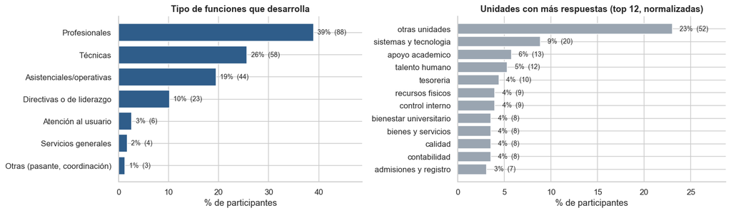

```
Unidades distintas (tras normalizar): 26 - dispersión alta: se analiza principalmente por tipo de funciones.
```

```python
fig, axes = plt.subplots(1,2, figsize=(14,4.2), gridspec_kw={'width_ratios':[1,1.1]})
barh_pct(df['funciones'].value_counts(), 'Tipo de funciones que desarrolla', ax=axes[0])
barh_pct(df['unidad_norm'].value_counts().head(12), 'Unidades con más respuestas (top 12, normalizadas)', color=GRIS, ax=axes[1])
plt.tight_layout(); plt.show()
print('Unidades distintas (tras normalizar):', df['unidad_norm'].nunique(), '- dispersión alta: se analiza principalmente por tipo de funciones.')
```

**Lectura:** la muestra está compuesta principalmente por perfiles profesionales y técnicos; los perfiles directivos y de atención al usuario son minoritarios, por lo que sus resultados se leen con cautela. La variable *unidad* está muy fragmentada (texto libre), por eso los cruces se hacen por tipo de funciones.

## 3. Nivel de uso y frecuencia

**Preguntas de la encuesta utilizadas en esta sección**

| Gráfica / análisis | Pregunta(s) usada(s) |
| --- | --- |
| Gráfica "¿Ha utilizado IA para apoyar su trabajo?" | **P3.** ¿Ha utilizado herramientas de inteligencia artificial para apoyar actividades relacionadas con su trabajo? |
| Gráfica "Frecuencia de uso" y cifras de uso intensivo | **P4.** ¿Con qué frecuencia utiliza IA en actividades laborales? |
| Gráfica "Forma de uso de la IA (madurez)" | **P7.** Cuando utiliza IA, ¿cuál de estas situaciones describe mejor su forma de uso? |

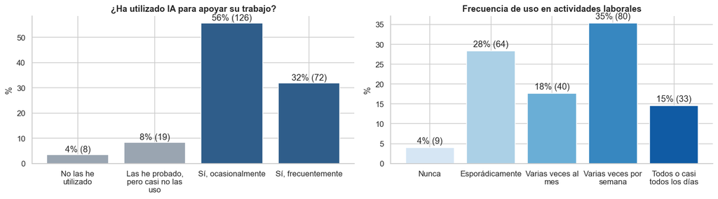

```
Han usado IA alguna vez en el trabajo: 96.5%
Uso intensivo (varias veces/semana o a diario): 50.0%
Nunca usan: 4.0%
```

```python
fig, axes = plt.subplots(1,2, figsize=(14,4))
u = df['uso_ia'].value_counts().reindex(orden_uso).dropna()
axes[0].bar([etiqueta(i,18) for i in u.index], u.values/len(df)*100, color=[GRIS,GRIS,AZUL,AZUL])
for i,v in enumerate(u.values): axes[0].text(i, v/len(df)*100+1, f'{v/len(df)*100:.0f}% ({v})', ha='center')
axes[0].set(title='¿Ha utilizado IA para apoyar su trabajo?', ylabel='%')
fr = df['frecuencia'].value_counts().reindex(orden_freq)
axes[1].bar([etiqueta(i,16) for i in fr.index], fr.values/len(df)*100, color=sns.color_palette('Blues', 5))
for i,v in enumerate(fr.values): axes[1].text(i, v/len(df)*100+1, f'{v/len(df)*100:.0f}% ({v})', ha='center')
axes[1].set(title='Frecuencia de uso en actividades laborales', ylabel='%')
plt.tight_layout(); plt.show()

usa = (~df['uso_ia'].isin(['No las he utilizado'])).sum()
reg = df['frecuencia'].isin(['Varias veces por semana','Todos o casi todos los días']).sum()
print(f"Han usado IA alguna vez en el trabajo: {usa/len(df):.1%}")
print(f"Uso intensivo (varias veces/semana o a diario): {reg/len(df):.1%}")
print(f"Nunca usan: {(df['frecuencia']=='Nunca').mean():.1%}")
```

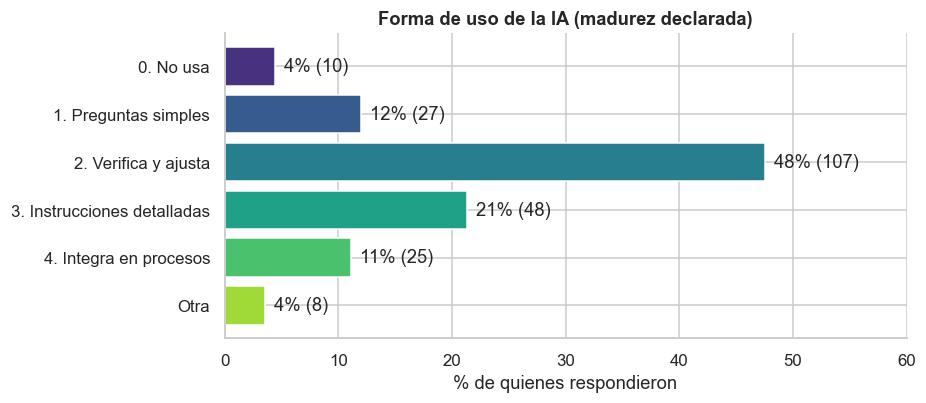

```python
# Forma de uso (madurez)
m = df['madurez'].value_counts().sort_index()
fig, ax = plt.subplots(figsize=(8,3.6))
ax.barh(m.index[::-1], m.values[::-1]/m.sum()*100, color=sns.color_palette('viridis', len(m))[::-1])
for y,v in enumerate(m.values[::-1]): ax.text(v/m.sum()*100+.8, y, f'{v/m.sum()*100:.0f}% ({v})', va='center')
ax.set(title='Forma de uso de la IA (madurez declarada)', xlabel='% de quienes respondieron'); ax.set_xlim(0,60)
plt.show()
```

**Lectura:** la gran mayoría ya ha usado IA y la mitad (50%) la emplea al menos varias veces por semana: la adopción básica es alta. El patrón dominante es el uso *crítico* (comparar, verificar y ajustar), mientras que la integración de la IA en varias etapas del proceso es todavía minoritaria: la brecha está en pasar del uso individual a la apropiación en procesos.

## 4. Herramientas y actividades

**Preguntas de la encuesta utilizadas en esta sección**

| Gráfica / análisis | Pregunta(s) usada(s) |
| --- | --- |
| Gráfica "Herramientas de IA utilizadas" | **P5.** ¿Qué herramientas de IA utiliza actualmente para actividades relacionadas con su trabajo? (varias) |
| Gráfica "Actividades en las que se usa IA" | **P6.** ¿Para cuáles actividades utiliza o ha utilizado IA? (varias) |
| Mapa de coincidencia entre herramientas y nº de herramientas por persona | **P5.** ¿Qué herramientas de IA utiliza actualmente para actividades relacionadas con su trabajo? (varias) |

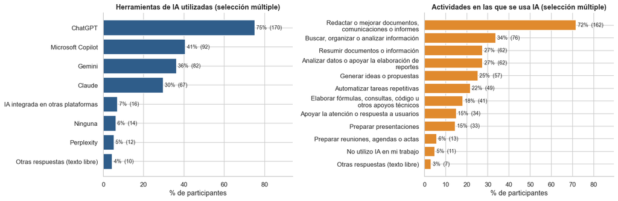

```python
fig, axes = plt.subplots(1,2, figsize=(15,5))
h = conteo('herramientas', 10).rename({'Herramientas de IA incorporadas en otros programas o plataformas':'IA integrada en otras plataformas'})
barh_pct(h, 'Herramientas de IA utilizadas (selección múltiple)', ax=axes[0])
a = conteo('actividades', 10); a.index=[etiqueta(i,42) for i in a.index]
barh_pct(a, 'Actividades en las que se usa IA (selección múltiple)', color=NARANJA, ax=axes[1])
plt.tight_layout(); plt.show()
```

```
Promedio de herramientas principales por persona: 1.87
```

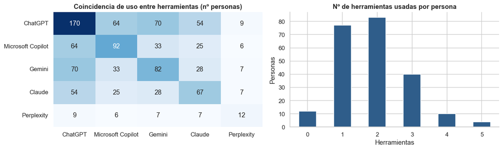

```python
# Número de herramientas por persona y co-uso de herramientas
principales = ['ChatGPT','Microsoft Copilot','Gemini','Claude','Perplexity']
H = dummies('herramientas', principales)
df['n_herr'] = H.sum(axis=1)
print('Promedio de herramientas principales por persona:', df['n_herr'].mean().round(2))
co = H.astype(int).T.dot(H.astype(int))
fig, axes = plt.subplots(1,2, figsize=(13,4))
sns.heatmap(co, annot=True, fmt='d', cmap='Blues', cbar=False, ax=axes[0]); axes[0].set_title('Coincidencia de uso entre herramientas (nº personas)')
df['n_herr'].value_counts().sort_index().plot.bar(color=AZUL, ax=axes[1], rot=0)
axes[1].set(title='Nº de herramientas usadas por persona', xlabel='Herramientas', ylabel='Personas')
plt.tight_layout(); plt.show()
```

**Lectura:** ChatGPT es la herramienta de referencia, seguida de Copilot, Gemini y Claude; el ecosistema es fragmentado, con uso simultáneo de varias herramientas, lo que anticipa riesgos de gobierno de datos. Los usos se concentran en **redactar/mejorar documentos** y, en menor medida, buscar, resumir y analizar información; los usos de mayor valor (automatizar, código, atención a usuarios) son menos frecuentes.

## 5. Competencias autopercibidas

**Preguntas de la encuesta utilizadas en esta sección**

| Gráfica / análisis | Pregunta(s) usada(s) |
| --- | --- |
| Gráfica "Autopercepción de competencias" y tabla de medias | **P8.** Competencia: Formular instrucciones claras a una herramienta de IA **P9.** Competencia: Evaluar si una respuesta de IA es correcta o confiable **P10.** Competencia: Utilizar IA para analizar i… |
| Correlación competencias vs. frecuencia (Spearman) | **P8.** Competencia: Formular instrucciones claras a una herramienta de IA **P9.** Competencia: Evaluar si una respuesta de IA es correcta o confiable **P10.** Competencia: Utilizar IA para analizar i… |

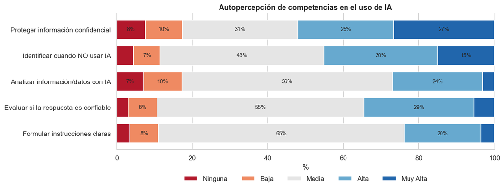

|  | Media (0-4) | % Alta o Muy alta | % Ninguna o Baja |
| --- | --- | --- | --- |
| Formular instrucciones claras | 2.1 | 23.9 | 11.1 |
| Analizar información/datos con IA | 2.1 | 27.0 | 17.3 |
| Evaluar si la respuesta es confiable | 2.3 | 34.5 | 10.6 |
| Identificar cuándo NO usar IA | 2.4 | 45.1 | 11.5 |
| Proteger información confidencial | 2.5 | 51.8 | 17.3 |

```python
comp = pd.DataFrame({comp_lbl[c]: df[c].value_counts(normalize=True).reindex(orden_comp).fillna(0)*100 for c in comp_cols}).T
colores = ['#B2182B','#EF8A62','#E5E5E5','#67A9CF','#2166AC']
ax = comp.plot.barh(stacked=True, color=colores, figsize=(11,4), width=.75)
for i,(idx,row) in enumerate(comp.iterrows()):
    x=0
    for v in row:
        if v>=6: ax.text(x+v/2, i, f'{v:.0f}%', ha='center', va='center', fontsize=9)
        x+=v
ax.set(title='Autopercepción de competencias en el uso de IA', xlabel='%', xlim=(0,100)); ax.legend(ncol=5, loc='upper center', bbox_to_anchor=(.5,-.15), frameon=False)
plt.show()
res = pd.DataFrame({'Media (0-4)':[df[c+'_n'].mean() for c in comp_cols], '% Alta o Muy alta':[df[c].isin(['Alta','Muy Alta']).mean()*100 for c in comp_cols],
                    '% Ninguna o Baja':[df[c].isin(['Ninguna','Baja']).mean()*100 for c in comp_cols]}, index=[comp_lbl[c] for c in comp_cols]).round(1)
res.sort_values('Media (0-4)')
```

```
                         Competencia  rho vs frecuencia p-valor
       Formular instrucciones claras               0.36 1.6e-08
Evaluar si la respuesta es confiable               0.28 2.4e-05
   Analizar información/datos con IA               0.34 2.2e-07
       Identificar cuándo NO usar IA               0.27 2.9e-05
   Proteger información confidencial               0.21 1.5e-03
```

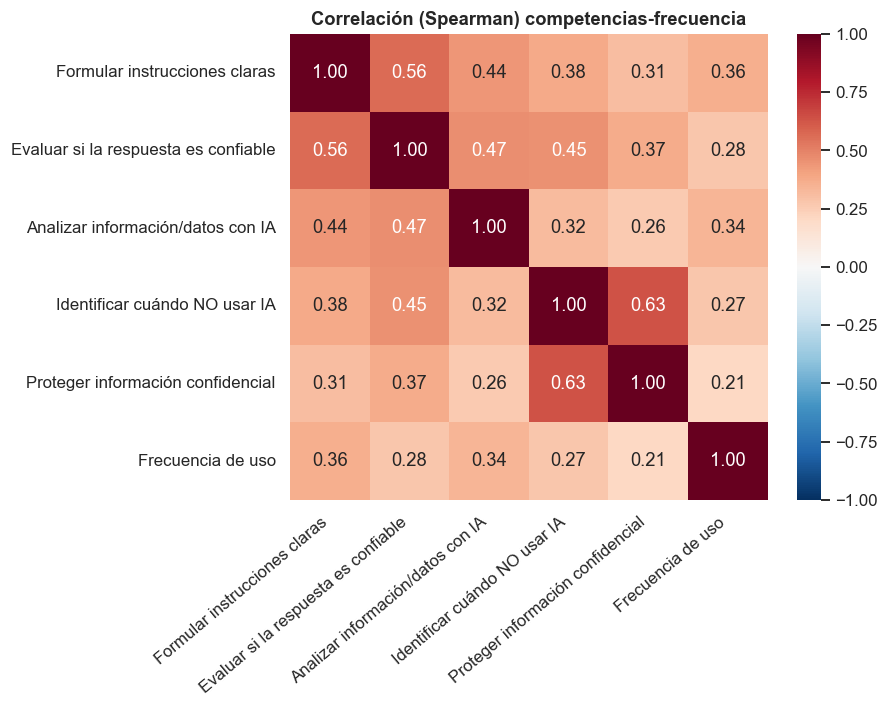

```python
# ¿Se relacionan las competencias con la frecuencia de uso? (Spearman)
rows=[]
for c in comp_cols:
    r,p = stats.spearmanr(df[c+'_n'], df['freq_n'], nan_policy='omit'); rows.append((comp_lbl[c], round(r,2), f'{p:.1e}'))
print(pd.DataFrame(rows, columns=['Competencia','rho vs frecuencia','p-valor']).to_string(index=False))
fig, ax = plt.subplots(figsize=(7,5.5))
cm = df[[c+'_n' for c in comp_cols]+['freq_n']].rename(columns={**{c+'_n':comp_lbl[c] for c in comp_cols},'freq_n':'Frecuencia de uso'}).corr(method='spearman')
sns.heatmap(cm, annot=True, fmt='.2f', cmap='RdBu_r', center=0, vmin=-1, vmax=1, ax=ax); ax.set_title('Correlación (Spearman) competencias-frecuencia')
plt.xticks(rotation=40, ha='right'); plt.show()
```

### ¿Cómo leer la tabla de correlaciones?

La tabla anterior responde una pregunta: **¿quienes usan la IA con más frecuencia también se califican como más competentes?**

**Qué se hizo.** Para cada una de las 5 competencias (P8 a P12) se calculó la correlación de Spearman con la frecuencia de uso (P4). Spearman se usa con variables ordinales (por ejemplo "Baja / Media / Alta" o "Esporádicamente / Varias veces por semana") porque compara posiciones y no distancias exactas.

**Cómo leer las columnas**

- **rho** va de -1 a +1. Cerca de 0 no hay relación; positivo significa que a más frecuencia de uso, mayor competencia declarada; negativo significa lo contrario.
- **p-valor** es la probabilidad de observar una relación así si en realidad no existiera ninguna. Si es menor que 0,05, se considera que la relación no es casualidad. Aquí todos son muy pequeños (el mayor es 0,0015), así que ninguna se explica por azar.

**Qué dicen los resultados**

| Competencia | rho | Lectura |
| --- | --- | --- |
| Formular instrucciones claras | 0,36 | La más ligada a la frecuencia de uso |
| Analizar información/datos con IA | 0,34 | Casi igual de ligada |
| Evaluar si la respuesta es confiable | 0,28 | Relación débil a moderada |
| Identificar cuándo NO usar IA | 0,27 | Relación débil a moderada |
| Proteger información confidencial | 0,21 | La más débil |

Todas son positivas, pero ninguna supera 0,36: por convención son relaciones **débiles a moderadas**. La frecuencia explica solo una parte de la competencia declarada.

**Interpretación**

- Las competencias más asociadas con la frecuencia son las **prácticas** (redactar instrucciones, analizar datos), que se desarrollan usando la herramienta.
- Las menos asociadas son las de **criterio y cuidado** (proteger información, saber cuándo no usar IA). Es una pista que convendría comprobar: esas competencias dependen menos de usar mucho la IA, por lo que probablemente requieren orientación o formación específica y no solo práctica.

**Lo que NO se puede afirmar**

- **Causalidad:** no se sabe si usar más hace sentirse más competente, o si quien ya se siente competente usa más.
- **Competencia real:** son competencias autopercibidas; quien usa más puede simplemente sentirse más seguro.
- **Fuerza de la relación:** un p-valor pequeño solo indica que la relación existe, no que sea grande. Con 226 personas, incluso relaciones modestas resultan significativas.

**Lectura:** la autopercepción es mayoritariamente *media*. Las competencias se asocian positivamente con la frecuencia de uso: practicar más va de la mano con sentirse más competente (la dirección causal no puede establecerse con una encuesta). La fortaleza relativa está en proteger la información confidencial (media 2,5) e identificar cuándo no usar IA; las menores en formular instrucciones claras y analizar datos con IA (media 2,1), que además son las que más se asocian con la frecuencia de uso, es decir, las que más se desarrollan practicando.

## 6. Beneficios y cambio en la forma de trabajar

**Preguntas de la encuesta utilizadas en esta sección**

| Gráfica / análisis | Pregunta(s) usada(s) |
| --- | --- |
| Gráfica "Beneficios percibidos" | **P13.** Cuando utiliza IA, ¿qué beneficios ha experimentado? (varias) |
| Gráfica "Cuánto ha cambiado la IA su forma de trabajar" | **P14.** En términos generales, ¿cuánto considera que la IA ha cambiado su forma de trabajar? |

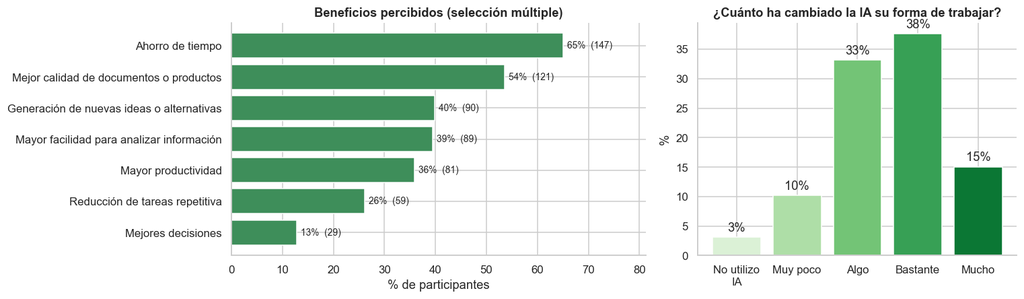

```
Perciben cambio 'Bastante' o 'Mucho': 52.7%
```

```python
fig, axes = plt.subplots(1,2, figsize=(14,4.2), gridspec_kw={'width_ratios':[1.3,1]})
b = conteo('beneficios', 5).drop(['No utilizo IA','Otras respuestas (texto libre)'], errors='ignore')
barh_pct(b, 'Beneficios percibidos (selección múltiple)', color='#3E8E5A', ax=axes[0])
ch = df['cambio_trabajo'].value_counts().reindex(orden_cambio)
axes[1].bar([etiqueta(i,10) for i in ch.index], ch.values/len(df)*100, color=sns.color_palette('Greens', 5))
for i,v in enumerate(ch.values): axes[1].text(i, v/len(df)*100+1, f'{v/len(df)*100:.0f}%', ha='center')
axes[1].set(title='¿Cuánto ha cambiado la IA su forma de trabajar?', ylabel='%')
plt.tight_layout(); plt.show()
print(f"Perciben cambio 'Bastante' o 'Mucho': {df['cambio_trabajo'].isin(['Bastante','Mucho']).mean():.1%}")
```

**Lectura:** el beneficio dominante es el **ahorro de tiempo**, seguido de la mejor calidad de los productos; los beneficios estratégicos (mejores decisiones) son los menos mencionados. La mayoría percibe un cambio real en su forma de trabajar.

## 7. Barreras, riesgos y gobernanza

**Preguntas de la encuesta utilizadas en esta sección**

| Gráfica / análisis | Pregunta(s) usada(s) |
| --- | --- |
| Gráfica "Principales dificultades" y barreras por categoría | **P15.** ¿Qué le dificulta utilizar más o mejor la IA en su trabajo? (máx. 3) |
| Gráfica "Claridad sobre orientaciones institucionales" | **P16.** ¿Tiene claridad sobre las orientaciones institucionales para el uso responsable y seguro de IA? |

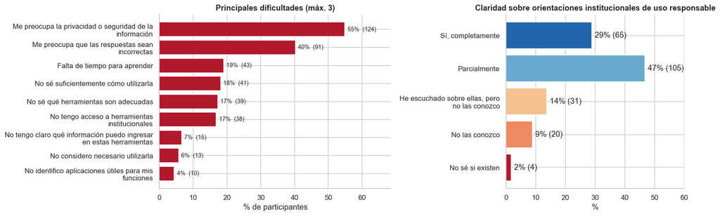

```
Conocen completamente las orientaciones: 28.9%
No las conocen / no saben si existen / solo han oído de ellas: 24.4%
```

```python
fig, axes = plt.subplots(1,2, figsize=(15,4.8), gridspec_kw={'width_ratios':[1.3,1]})
br = conteo('barreras', 10).drop('Otras respuestas (texto libre)', errors='ignore'); br.index=[etiqueta(i,45) for i in br.index]
barh_pct(br, 'Principales dificultades (máx. 3)', color='#B2182B', ax=axes[0])
cl = df['claridad_inst'].value_counts().reindex(orden_claridad)
n_cl = cl.sum()
axes[1].barh([etiqueta(i,32) for i in cl.index], cl.values/n_cl*100, color=['#B2182B','#EF8A62','#F4C28F','#67A9CF','#2166AC'])
for y,v in enumerate(cl.values): axes[1].text(v/n_cl*100+1, y, f'{v/n_cl*100:.0f}% ({v})', va='center')
axes[1].set(title='Claridad sobre orientaciones institucionales de uso responsable', xlabel='%', xlim=(0,60))
plt.tight_layout(); plt.show()
print(f"Conocen completamente las orientaciones: {(df['claridad_inst']=='Sí, completamente').sum()/n_cl:.1%}")
print(f"No las conocen / no saben si existen / solo han oído de ellas: {(~df['claridad_inst'].isin(['Sí, completamente','Parcialmente']) & df['claridad_inst'].notna()).sum()/n_cl:.1%}")
```

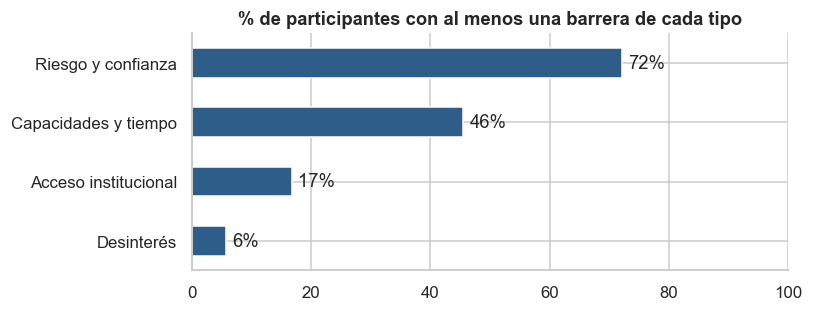

```python
# Agrupar barreras por categoría
cat = {'Riesgo y confianza':['Me preocupa la privacidad o seguridad de la información','Me preocupa que las respuestas sean incorrectas','No tengo claro qué información puedo ingresar en estas herramientas'],
       'Capacidades y tiempo':['Falta de tiempo para aprender','No sé suficientemente cómo utilizarla','No sé qué herramientas son adecuadas','No identifico aplicaciones útiles para mis funciones'],
       'Acceso institucional':['No tengo acceso a herramientas institucionales'],
       'Desinterés':['No considero necesario utilizarla']}
tot = pd.Series({k: df['barreras'].map(lambda s: any(i in split_multi(s) for i in v)).mean()*100 for k,v in cat.items()}).sort_values()
ax = tot.plot.barh(color=AZUL, figsize=(7,2.8))
for y,v in enumerate(tot): ax.text(v+1, y, f'{v:.0f}%', va='center')
ax.set(title='% de participantes con al menos una barrera de cada tipo', xlim=(0,100)); plt.show()
```

**Lectura:** la **privacidad/seguridad** y la **fiabilidad de las respuestas** son las principales preocupaciones; le siguen la falta de tiempo y de conocimiento. Solo el 29% conoce completamente las orientaciones institucionales y cerca de una cuarta parte no las conoce o solo ha oído de ellas: existe una brecha de gobernanza y comunicación que coincide con el riesgo percibido.

## 8. Oportunidades y necesidades de apoyo

**Preguntas de la encuesta utilizadas en esta sección**

| Gráfica / análisis | Pregunta(s) usada(s) |
| --- | --- |
| Gráfica "Actividades donde la IA podría ayudar más" | **P17.** Pensando en sus funciones actuales, ¿en cuáles actividades considera que la IA podría ayudarle más, aunque todavía no la utilice? (varias) |
| Gráfica "Apoyos prioritarios" | **P18.** ¿Qué tipo de apoyo considera prioritario para fortalecer el uso de IA en su trabajo? (máx. 2) |
| Gráfica "Uso actual vs. potencial percibido" y tabla de brechas | **P6.** ¿Para cuáles actividades utiliza o ha utilizado IA? (varias) **P17.** Pensando en sus funciones actuales, ¿en cuáles actividades considera que la IA podría ayudarle más, aunque todavía no la u… |

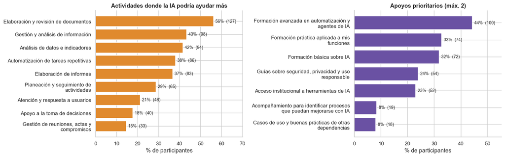

```python
fig, axes = plt.subplots(1,2, figsize=(15,4.8))
op = conteo('oportunidades', 10).drop('Otras respuestas (texto libre)', errors='ignore'); op.index=[etiqueta(i,38) for i in op.index]
barh_pct(op, 'Actividades donde la IA podría ayudar más', color=NARANJA, ax=axes[0])
ap = conteo('apoyos', 10).drop('Otras respuestas (texto libre)', errors='ignore'); ap.index=[etiqueta(i,42) for i in ap.index]
barh_pct(ap, 'Apoyos prioritarios (máx. 2)', color='#6A51A3', ax=axes[1])
plt.tight_layout(); plt.show()
```

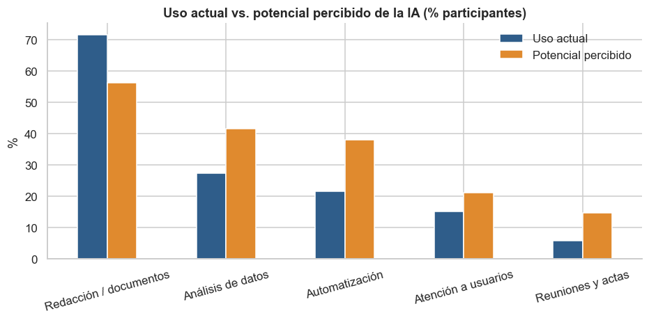

|  | Uso actual | Potencial percibido | Brecha (pp) |
| --- | --- | --- | --- |
| Redacción / documentos | 71.7 | 56.2 | -15.5 |
| Análisis de datos | 27.4 | 41.6 | 14.2 |
| Automatización | 21.7 | 38.1 | 16.4 |
| Atención a usuarios | 15.0 | 21.2 | 6.2 |
| Reuniones y actas | 5.8 | 14.6 | 8.8 |

```python
# Brecha: uso actual vs potencial percibido (actividades comparables)
par = {'Redacción / documentos':('Redactar o mejorar documentos, comunicaciones o informes','Elaboración y revisión de documentos'),
       'Análisis de datos':('Analizar datos o apoyar la elaboración de reportes','Análisis de datos e indicadores'),
       'Automatización':('Automatizar tareas repetitivas','Automatización de tareas repetitivas'),
       'Atención a usuarios':('Apoyar la atención o respuesta a usuarios','Atención y respuesta a usuarios'),
       'Reuniones y actas':('Preparar reuniones, agendas o actas','Gestión de reuniones, actas y compromisos')}
uso_a = {k: df['actividades'].map(lambda s: v[0] in split_multi(s)).mean()*100 for k,v in par.items()}
pot_a = {k: df['oportunidades'].map(lambda s: v[1] in split_multi(s)).mean()*100 for k,v in par.items()}
g = pd.DataFrame({'Uso actual':uso_a,'Potencial percibido':pot_a}); g['Brecha (pp)']=(g['Potencial percibido']-g['Uso actual']).round(1)
ax = g[['Uso actual','Potencial percibido']].plot.bar(color=[AZUL,NARANJA], figsize=(10,4), rot=15)
ax.set(title='Uso actual vs. potencial percibido de la IA (% participantes)', ylabel='%'); ax.legend(frameon=False); plt.show()
g.round(1)
```

**Lectura:** la formación **avanzada en automatización y agentes de IA** encabeza la demanda, por delante de la formación práctica aplicada y la básica: el personal pide pasar de lo básico a la automatización. También solicitan guías de seguridad/privacidad y acceso institucional a herramientas, que responden directamente a las barreras identificadas. La redacción ya está muy extendida (72% la usa, 56% ve más potencial: es el uso consolidado), mientras que automatización (+16 pp) y análisis de datos (+14 pp) muestran la mayor brecha entre uso actual y potencial percibido.

## 9. Tareas repetitivas propuestas (pregunta abierta)

**Preguntas de la encuesta utilizadas en esta sección**

| Gráfica / análisis | Pregunta(s) usada(s) |
| --- | --- |
| Gráfica de temas por palabras clave, palabras más frecuentes y ejemplos | **P19.** Mencione una tarea o proceso que le tome mucho tiempo o sea repetitivo y que podría mejorarse con IA (abierta) |

```
Respuestas: 147 | útiles: 126 (56% del total)
```

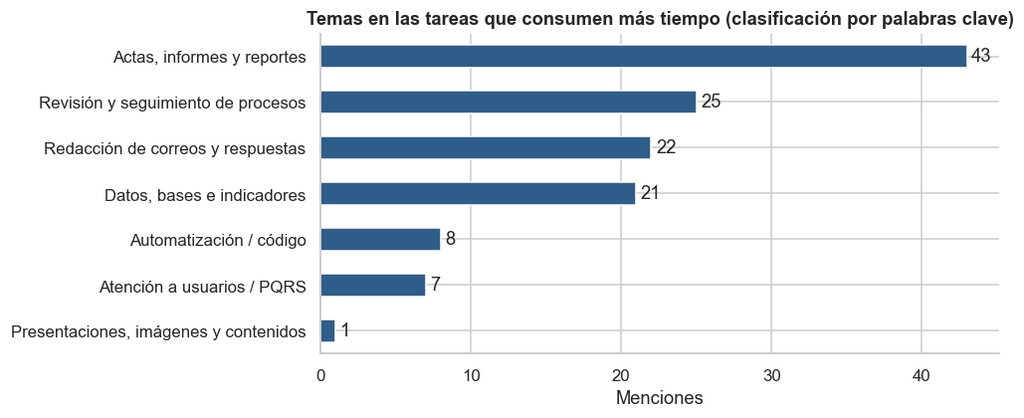

```
Nota: una respuesta puede pertenecer a varios temas.
```

|  | Ejemplos de respuestas |
| --- | --- |
| 0 | Encontrar la documentación disponible en la gaceta normativa, que relacionando con palabras clav... |
| 1 | Los informes |
| 2 | La realización de las actas de las visitas de pares académicos |
| 3 | Manejo de club, ya que existen aplicativos que facilitan |
| 4 | Análisis de correos y respuestas |
| 5 | Revisión de ABS |
| 6 | Actas |
| 7 | Organizar matrices de datos, desde la información de las plataformas institucionales |
| 8 | Conciliaciones |
| 9 | Las matrices de información |
| 10 | Envío de correos para el seguimiento de finalización de procesos |
| 11 | Informes institucionales |

```python
txt = df['tarea_abierta'].dropna().astype(str).str.strip()
vacios = txt.str.lower().str.replace(r'[^a-záéíóúñ]','',regex=True).isin(['','ninguna','ninguno','na','no','nada','noaplica','nose'])
validas = txt[~vacios & (txt.str.len()>4)]
print(f'Respuestas: {len(txt)} | útiles: {len(validas)} ({len(validas)/len(df):.0%} del total)')

temas = {
 'Redacción de correos y respuestas': r'correo|respuesta|oficio|carta|comunicaci',
 'Actas, informes y reportes':        r'acta|informe|reporte|document|redacci|formato',
 'Datos, bases e indicadores':        r'dato|base|indicador|excel|conciliaci|estad|analisis|análisis|presupuesto|contab|factur',
 'Revisión y seguimiento de procesos':r'revisi|seguimiento|verific|control|plan|contrat|archivo|radicad',
 'Automatización / código':           r'automat|código|codigo|software|program|script|repetitiv',
 'Atención a usuarios / PQRS':        r'atenci|usuario|pqrs|estudiante|solicitud|cita',
 'Presentaciones, imágenes y contenidos': r'presentaci|imagen|dise|grafic|gráfic|contenido|recurso|video'}
tab = pd.Series({k: validas.str.lower().str.contains(v, regex=True).sum() for k,v in temas.items()}).sort_values()
ax = tab.plot.barh(color=AZUL, figsize=(8,3.8))
for y,v in enumerate(tab.values): ax.text(v+.3, y, str(v), va='center')
ax.set(title='Temas en las tareas que consumen más tiempo (clasificación por palabras clave)', xlabel='Menciones'); plt.show()
print('Nota: una respuesta puede pertenecer a varios temas.')
pd.DataFrame({'Ejemplos de respuestas':validas.sample(12, random_state=3).values})
```

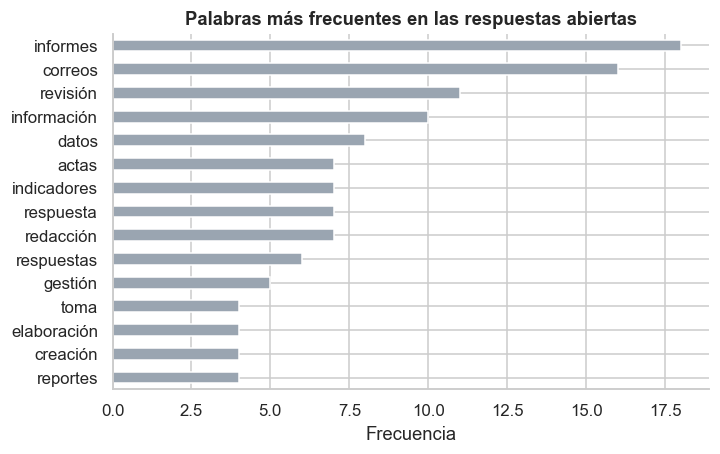

```python
# Palabras más frecuentes
stop = set('de la el en y a los las del que un una para con por se al es su lo como mas más o me mi le muy son tareas tarea proceso procesos realizar realizacion elaboracion cada sus este esta entre sin sobre'.split())
palabras = Counter(w for t in validas.str.lower() for w in re.findall(r'[a-záéíóúñ]{4,}', t) if w not in stop)
w = pd.Series(dict(palabras.most_common(15))).sort_values()
ax = w.plot.barh(color=GRIS, figsize=(7,4.2)); ax.set(title='Palabras más frecuentes en las respuestas abiertas', xlabel='Frecuencia'); plt.show()
```

**Lectura:** las tareas candidatas a automatizar con IA son administrativas y recurrentes (correos, actas e informes, consolidación de datos e indicadores, seguimiento de procesos). Son casos de uso concretos para priorizar en pilotos institucionales.

## 10. Segmentación por nivel de apropiación y cruces

**Preguntas de la encuesta utilizadas en esta sección**

| Gráfica / análisis | Pregunta(s) usada(s) |
| --- | --- |
| Índice de apropiación (0 a 100) y niveles Inicial/Básico/Intermedio/Avanzado (frecuencia 40%, competencias 40%, amplitud de actividades 20%) | **P4.** ¿Con qué frecuencia utiliza IA en actividades laborales? **P8.** Competencia: Formular instrucciones claras a una herramienta de IA **P9.** Competencia: Evaluar si una respuesta de IA es corre… |
| Nivel según tipo de funciones (χ², Kruskal-Wallis) | **P2.** Tipo de funciones que desarrolla principalmente |
| Claridad institucional según nivel | **P16.** ¿Tiene claridad sobre las orientaciones institucionales para el uso responsable y seguro de IA? |
| Mapas de calor de barreras y apoyos por nivel | **P15.** ¿Qué le dificulta utilizar más o mejor la IA en su trabajo? (máx. 3) **P18.** ¿Qué tipo de apoyo considera prioritario para fortalecer el uso de IA en su trabajo? (máx. 2) |

### ¿Cómo se calcula el índice de apropiación?

El índice (de 0 a 100) es una construcción propia de este análisis, no una pregunta de la encuesta. Combina tres preguntas, cada una llevada a una escala de 0 a 1:

| Componente | Pregunta | Cómo se convierte | Peso |
| --- | --- | --- | --- |
| **Frecuencia de uso** | P4 | Nunca=0, Esporádicamente=1, Varias veces al mes=2, Varias veces por semana=3, Todos o casi todos los días=4. Se divide entre 4. | 40% |
| **Competencias** | P8 a P12 | Ninguna=0, Baja=1, Media=2, Alta=3, Muy Alta=4. Se promedian las 5 competencias y se divide entre 4. | 40% |
| **Amplitud de uso** | P6 | Se cuentan las actividades marcadas, con tope en 6, y se divide entre 6. | 20% |

**Fórmula**

$$\text{Índice} = \left(0{,}4 \times \frac{\text{frecuencia}}{4} + 0{,}4 \times \frac{\text{promedio competencias}}{4} + 0{,}2 \times \frac{\min(\text{actividades},\,6)}{6}\right) \times 100$$

**Ejemplo:** una persona que usa IA "Varias veces al mes" (2), se califica "Media" en las 5 competencias (promedio 2) y marcó 2 actividades:

- Frecuencia: 0,4 × 2/4 = 0,20
- Competencias: 0,4 × 2/4 = 0,20
- Actividades: 0,2 × 2/6 = 0,067
- Índice = 0,467 × 100 ≈ **47 → Intermedio**

**Niveles:** Inicial (0 a 25), Básico (más de 25 hasta 45), Intermedio (más de 45 hasta 65), Avanzado (más de 65).

**Detalles del cálculo**

- En amplitud solo se cuentan las 9 actividades marcadas por al menos 30 personas; no suman las respuestas escritas en "Otro" ni "Preparar reuniones, agendas o actas" (13 menciones).
- Si a una persona le falta una competencia, se promedian las que respondió (un caso).

**Criterios y alcance**

- Los tres componentes reflejan el objetivo del diagnóstico: **uso** (frecuencia), **conocimiento** (competencias) y **apropiación** (variedad de usos). Amplitud pesa menos y tiene tope en 6 porque marcar muchas opciones es más fácil que usar la IA con frecuencia.
- Los pesos y los cortes de nivel son definidos por el analista y no están validados. El orden entre tipos de funciones se mantiene con otros pesos (solo frecuencia, solo competencias, solo actividades o pesos iguales); lo que sí cambia con otros cortes es cuántas personas quedan en cada nivel.
- Todos los componentes son autorreportados: miden uso y competencia **declarados**, no desempeño real.
- No incluye P7 (forma de uso), que también describe madurez. Una persona que nunca usa IA pero se califica "Media" en competencias obtiene 20 puntos.

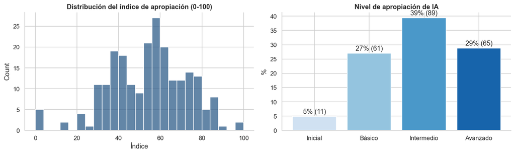

```python
# Índice de apropiación (0-100): 40% frecuencia + 40% competencias (media) + 20% amplitud de actividades
acts = list(conteo('actividades', 30).drop('Otras respuestas (texto libre)', errors='ignore').index)
n_act = dummies('actividades', [a for a in acts if not a.startswith('No utilizo')]).sum(axis=1)
comp_media = df[[c+'_n' for c in comp_cols]].mean(axis=1)
df['indice'] = (0.4*df['freq_n']/4 + 0.4*comp_media/4 + 0.2*(n_act.clip(upper=6)/6))*100
labs=['Inicial','Básico','Intermedio','Avanzado']
df['nivel'] = pd.cut(df['indice'], bins=[-1,25,45,65,101], labels=labs)
fig, axes = plt.subplots(1,2, figsize=(13,4))
sns.histplot(df['indice'], bins=25, color=AZUL, ax=axes[0]); axes[0].set(title='Distribución del índice de apropiación (0-100)', xlabel='Índice')
nv = df['nivel'].value_counts().reindex(labs)
axes[1].bar(labs, nv.values/len(df)*100, color=sns.color_palette('Blues', 4))
for i,v in enumerate(nv.values): axes[1].text(i, v/len(df)*100+1, f'{v/len(df)*100:.0f}% ({v})', ha='center')
axes[1].set(title='Nivel de apropiación de IA', ylabel='%'); plt.tight_layout(); plt.show()
```

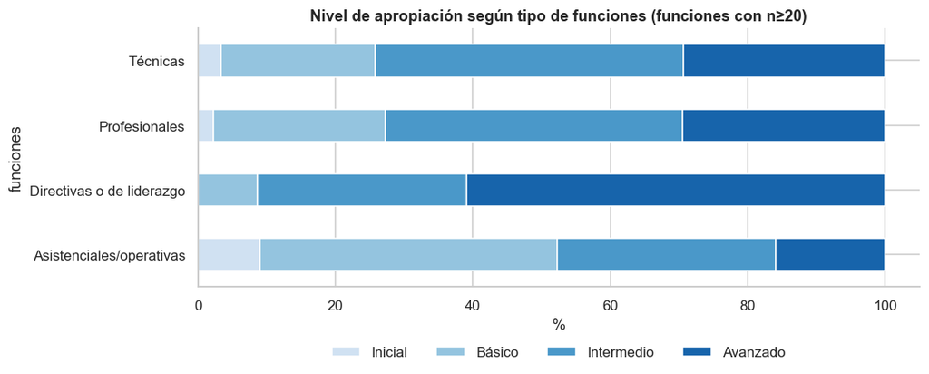

```
Chi² nivel vs funciones: χ²=24.6, gl=9, p=0.003
                           mean  median  count
funciones
Asistenciales/operativas   45.3    42.7     44
Directivas o de liderazgo  66.9    67.3     23
Profesionales              56.3    56.7     88
Técnicas                   55.0    58.0     58
Kruskal-Wallis: KruskalResult(statistic=np.float64(22.67733717911849), pvalue=np.float64(4.7144927151567415e-05))
```

```python
# Nivel por tipo de funciones
principales_f = df['funciones'].value_counts().loc[lambda s: s>=20].index
sub = df[df['funciones'].isin(principales_f)]
t = pd.crosstab(sub['funciones'], sub['nivel'], normalize='index').reindex(columns=labs)*100
ax = t.plot.barh(stacked=True, color=sns.color_palette('Blues', 4), figsize=(10,3.6))
ax.set(title='Nivel de apropiación según tipo de funciones (funciones con n≥20)', xlabel='%'); ax.legend(ncol=4, loc='upper center', bbox_to_anchor=(.5,-.18), frameon=False); plt.show()
ct = pd.crosstab(sub['funciones'], sub['nivel'])
chi2, p, dof, _ = stats.chi2_contingency(ct); print(f'Chi² nivel vs funciones: χ²={chi2:.1f}, gl={dof}, p={p:.3f}')
print(sub.groupby('funciones')['indice'].agg(['mean','median','count']).round(1))
print('Kruskal-Wallis:', stats.kruskal(*[g['indice'].values for _,g in sub.groupby('funciones')]))
```

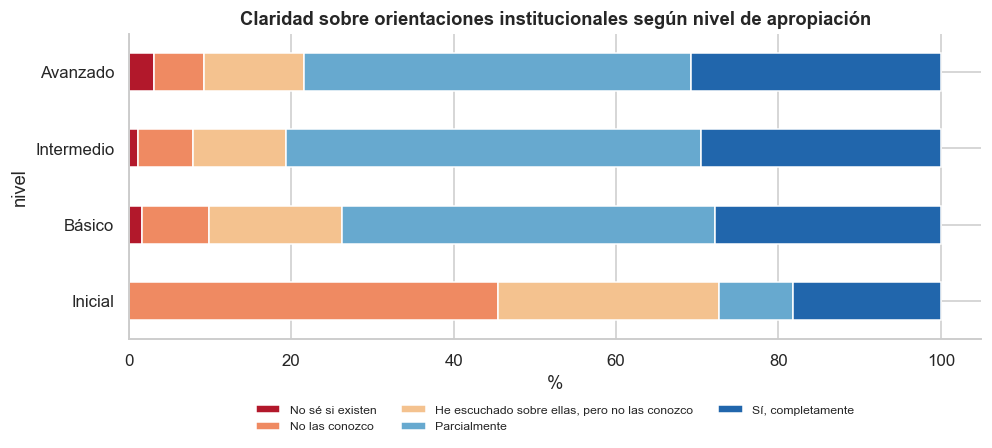

```
Spearman índice vs claridad: SignificanceResult(statistic=np.float64(0.12826609908384667), pvalue=np.float64(0.05470416745291728))
```

```python
# Gobernanza: ¿quienes más usan IA conocen más las orientaciones institucionales?
d = df.dropna(subset=['claridad_inst'])
t = pd.crosstab(d['nivel'], d['claridad_inst'], normalize='index').reindex(columns=orden_claridad)*100
ax = t.plot.barh(stacked=True, color=['#B2182B','#EF8A62','#F4C28F','#67A9CF','#2166AC'], figsize=(10,3.6))
ax.set(title='Claridad sobre orientaciones institucionales según nivel de apropiación', xlabel='%'); ax.legend(ncol=3, loc='upper center', bbox_to_anchor=(.5,-.18), frameon=False, fontsize=8); plt.show()
print('Spearman índice vs claridad:', stats.spearmanr(d['indice'], d['claridad_inst'].map({k:i for i,k in enumerate(orden_claridad)})))
```

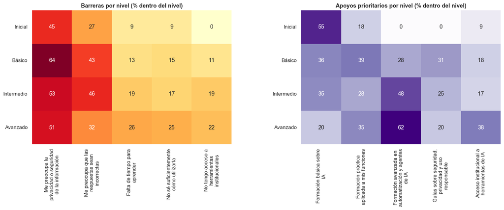

```
nivel
Inicial       11
Básico        61
Intermedio    89
Avanzado      65
```

```python
# Barreras y apoyos según nivel
bar_top = ['Me preocupa la privacidad o seguridad de la información','Me preocupa que las respuestas sean incorrectas','Falta de tiempo para aprender','No sé suficientemente cómo utilizarla','No tengo acceso a herramientas institucionales']
ap_top = ['Formación básica sobre IA','Formación práctica aplicada a mis funciones','Formación avanzada en automatización y agentes de IA','Guías sobre seguridad, privacidad y uso responsable','Acceso institucional a herramientas de IA']
fig, axes = plt.subplots(1,2, figsize=(18,5.2), gridspec_kw={'wspace':.35})
for ax,(col,lst,tit) in zip(axes,[('barreras',bar_top,'Barreras'),('apoyos',ap_top,'Apoyos prioritarios')]):
    D = dummies(col, lst); D['nivel']=df['nivel']
    M = D.groupby('nivel')[lst].mean().reindex(labs)*100
    M.columns=[etiqueta(c,24) for c in M.columns]
    sns.heatmap(M, annot=True, fmt='.0f', cmap='YlOrRd' if col=='barreras' else 'Purples', cbar=False, ax=ax); ax.set_title(f'{tit} por nivel (% dentro del nivel)'); ax.set_ylabel(''); ax.tick_params(axis='y', rotation=0)
plt.show()
print(df['nivel'].value_counts().reindex(labs).to_string())
```

## 11. Conclusiones

**Hallazgos clave**

1. **Adopción alta, apropiación incipiente.** La gran mayoría ya usa IA y la mitad la usa varias veces por semana, pero el uso se centra en redacción y búsqueda; la integración en procesos y la automatización son minoritarias.
2. **Uso crítico y competencias medias.** Predomina verificar y ajustar las respuestas; la autopercepción es mayoritariamente media.
3. **Valor percibido claro:** ahorro de tiempo y mejor calidad; pocas personas lo vinculan aún con mejores decisiones.
4. **Riesgo y gobernanza.** Las principales barreras son privacidad/seguridad y fiabilidad de las respuestas; solo el 29% conoce completamente las orientaciones institucionales, y el uso se hace con herramientas externas heterogéneas.
5. **Demanda de siguiente nivel.** La prioridad es la formación avanzada en automatización/agentes, junto con formación aplicada, guías de seguridad y acceso institucional.